# Optimal Treatment Analysis

## Outcome Variable

**Outcome Variable:** ever_stunted

## Predictor Variables

**Intervention Variable:** mbmi

**Adjustment Set:**

- arm
- W_mage
- meducyrs
- feducyrs
- single
- brthmon
- delta_W_mage
- delta_meducyrs
- delta_feducyrs
- delta_single
- delta_brthmon

## Stratifying Variables

The analysis was stratified on these variable(s):

- agecat
- studyid
- country

## Data Summary

| agecat | studyid | country | mbmi | ever_stunted | n_cell | n |
| --- | --- | --- | --- | --- | --- | --- |
| 0-24 months | ki0047075b-MAL-ED | BANGLADESH | Normal weight | 0 | 62 | 254 |
| 0-24 months | ki0047075b-MAL-ED | BANGLADESH | Normal weight | 1 | 101 | 254 |
| 0-24 months | ki0047075b-MAL-ED | BANGLADESH | Underweight | 0 | 9 | 254 |
| 0-24 months | ki0047075b-MAL-ED | BANGLADESH | Underweight | 1 | 23 | 254 |
| 0-24 months | ki0047075b-MAL-ED | BANGLADESH | Overweight or Obese | 0 | 28 | 254 |
| 0-24 months | ki0047075b-MAL-ED | BANGLADESH | Overweight or Obese | 1 | 31 | 254 |
| 0-24 months | ki0047075b-MAL-ED | BRAZIL | Normal weight | 0 | 73 | 221 |
| 0-24 months | ki0047075b-MAL-ED | BRAZIL | Normal weight | 1 | 15 | 221 |
| 0-24 months | ki0047075b-MAL-ED | BRAZIL | Underweight | 0 | 6 | 221 |
| 0-24 months | ki0047075b-MAL-ED | BRAZIL | Underweight | 1 | 4 | 221 |
| 0-24 months | ki0047075b-MAL-ED | BRAZIL | Overweight or Obese | 0 | 92 | 221 |
| 0-24 months | ki0047075b-MAL-ED | BRAZIL | Overweight or Obese | 1 | 31 | 221 |
| 0-24 months | ki0047075b-MAL-ED | INDIA | Normal weight | 0 | 52 | 242 |
| 0-24 months | ki0047075b-MAL-ED | INDIA | Normal weight | 1 | 90 | 242 |
| 0-24 months | ki0047075b-MAL-ED | INDIA | Underweight | 0 | 20 | 242 |
| 0-24 months | ki0047075b-MAL-ED | INDIA | Underweight | 1 | 29 | 242 |
| 0-24 months | ki0047075b-MAL-ED | INDIA | Overweight or Obese | 0 | 23 | 242 |
| 0-24 months | ki0047075b-MAL-ED | INDIA | Overweight or Obese | 1 | 28 | 242 |
| 0-24 months | ki0047075b-MAL-ED | NEPAL | Normal weight | 0 | 85 | 238 |
| 0-24 months | ki0047075b-MAL-ED | NEPAL | Normal weight | 1 | 49 | 238 |
| 0-24 months | ki0047075b-MAL-ED | NEPAL | Underweight | 0 | 0 | 238 |
| 0-24 months | ki0047075b-MAL-ED | NEPAL | Underweight | 1 | 0 | 238 |
| 0-24 months | ki0047075b-MAL-ED | NEPAL | Overweight or Obese | 0 | 71 | 238 |
| 0-24 months | ki0047075b-MAL-ED | NEPAL | Overweight or Obese | 1 | 33 | 238 |
| 0-24 months | ki0047075b-MAL-ED | PERU | Normal weight | 0 | 54 | 290 |
| 0-24 months | ki0047075b-MAL-ED | PERU | Normal weight | 1 | 105 | 290 |
| 0-24 months | ki0047075b-MAL-ED | PERU | Underweight | 0 | 2 | 290 |
| 0-24 months | ki0047075b-MAL-ED | PERU | Underweight | 1 | 3 | 290 |
| 0-24 months | ki0047075b-MAL-ED | PERU | Overweight or Obese | 0 | 48 | 290 |
| 0-24 months | ki0047075b-MAL-ED | PERU | Overweight or Obese | 1 | 78 | 290 |

[output cut: 252 more lines]

The following strata were considered:

- agecat: 0-24 months, studyid: ki0047075b-MAL-ED, country: BANGLADESH
- agecat: 0-24 months, studyid: ki0047075b-MAL-ED, country: BRAZIL
- agecat: 0-24 months, studyid: ki0047075b-MAL-ED, country: INDIA
- agecat: 0-24 months, studyid: ki0047075b-MAL-ED, country: NEPAL
- agecat: 0-24 months, studyid: ki0047075b-MAL-ED, country: PERU
- agecat: 0-24 months, studyid: ki0047075b-MAL-ED, country: SOUTH AFRICA
- agecat: 0-24 months, studyid: ki0047075b-MAL-ED, country: TANZANIA, UNITED REPUBLIC OF
- agecat: 0-24 months, studyid: ki1000304b-SAS-CompFeed, country: INDIA
- agecat: 0-24 months, studyid: ki1017093-NIH-Birth, country: BANGLADESH
- agecat: 0-24 months, studyid: ki1017093b-PROVIDE, country: BANGLADESH
- agecat: 0-24 months, studyid: ki1017093c-NIH-Crypto, country: BANGLADESH
- agecat: 0-24 months, studyid: ki1066203-TanzaniaChild2, country: TANZANIA, UNITED REPUBLIC OF
- agecat: 0-24 months, studyid: ki1112895-iLiNS-Zinc, country: BURKINA FASO
- agecat: 0-24 months, studyid: ki1119695-PROBIT, country: BELARUS
- agecat: 0-24 months, studyid: ki1126311-ZVITAMBO, country: ZIMBABWE
- agecat: 0-24 months, studyid: ki1148112-LCNI-5, country: MALAWI
- agecat: 0-6 months, studyid: ki0047075b-MAL-ED, country: BANGLADESH
- agecat: 0-6 months, studyid: ki0047075b-MAL-ED, country: BRAZIL
- agecat: 0-6 months, studyid: ki0047075b-MAL-ED, country: INDIA
- agecat: 0-6 months, studyid: ki0047075b-MAL-ED, country: NEPAL
- agecat: 0-6 months, studyid: ki0047075b-MAL-ED, country: PERU
- agecat: 0-6 months, studyid: ki0047075b-MAL-ED, country: SOUTH AFRICA
- agecat: 0-6 months, studyid: ki0047075b-MAL-ED, country: TANZANIA, UNITED REPUBLIC OF
- agecat: 0-6 months, studyid: ki1000304b-SAS-CompFeed, country: INDIA
- agecat: 0-6 months, studyid: ki1017093-NIH-Birth, country: BANGLADESH
- agecat: 0-6 months, studyid: ki1017093b-PROVIDE, country: BANGLADESH
- agecat: 0-6 months, studyid: ki1017093c-NIH-Crypto, country: BANGLADESH
- agecat: 0-6 months, studyid: ki1066203-TanzaniaChild2, country: TANZANIA, UNITED REPUBLIC OF
- agecat: 0-6 months, studyid: ki1119695-PROBIT, country: BELARUS
- agecat: 0-6 months, studyid: ki1126311-ZVITAMBO, country: ZIMBABWE
- agecat: 0-6 months, studyid: ki1148112-LCNI-5, country: MALAWI
- agecat: 6-24 months, studyid: ki0047075b-MAL-ED, country: BANGLADESH
- agecat: 6-24 months, studyid: ki0047075b-MAL-ED, country: BRAZIL
- agecat: 6-24 months, studyid: ki0047075b-MAL-ED, country: INDIA
- agecat: 6-24 months, studyid: ki0047075b-MAL-ED, country: NEPAL
- agecat: 6-24 months, studyid: ki0047075b-MAL-ED, country: PERU
- agecat: 6-24 months, studyid: ki0047075b-MAL-ED, country: SOUTH AFRICA
- agecat: 6-24 months, studyid: ki0047075b-MAL-ED, country: TANZANIA, UNITED REPUBLIC OF
- agecat: 6-24 months, studyid: ki1000304b-SAS-CompFeed, country: INDIA
- agecat: 6-24 months, studyid: ki1017093-NIH-Birth, country: BANGLADESH
- agecat: 6-24 months, studyid: ki1017093b-PROVIDE, country: BANGLADESH
- agecat: 6-24 months, studyid: ki1017093c-NIH-Crypto, country: BANGLADESH
- agecat: 6-24 months, studyid: ki1066203-TanzaniaChild2, country: TANZANIA, UNITED REPUBLIC OF
- agecat: 6-24 months, studyid: ki1112895-iLiNS-Zinc, country: BURKINA FASO
- agecat: 6-24 months, studyid: ki1119695-PROBIT, country: BELARUS
- agecat: 6-24 months, studyid: ki1126311-ZVITAMBO, country: ZIMBABWE
- agecat: 6-24 months, studyid: ki1148112-LCNI-5, country: MALAWI

### Dropped Strata

Some strata were dropped due to rare outcomes:

- agecat: 0-24 months, studyid: ki0047075b-MAL-ED, country: BRAZIL
- agecat: 0-24 months, studyid: ki0047075b-MAL-ED, country: NEPAL
- agecat: 0-24 months, studyid: ki0047075b-MAL-ED, country: PERU
- agecat: 0-24 months, studyid: ki0047075b-MAL-ED, country: SOUTH AFRICA
- agecat: 0-24 months, studyid: ki0047075b-MAL-ED, country: TANZANIA, UNITED REPUBLIC OF
- agecat: 0-6 months, studyid: ki0047075b-MAL-ED, country: BRAZIL
- agecat: 0-6 months, studyid: ki0047075b-MAL-ED, country: NEPAL
- agecat: 0-6 months, studyid: ki0047075b-MAL-ED, country: PERU
- agecat: 0-6 months, studyid: ki0047075b-MAL-ED, country: SOUTH AFRICA
- agecat: 0-6 months, studyid: ki1148112-LCNI-5, country: MALAWI
- agecat: 6-24 months, studyid: ki0047075b-MAL-ED, country: BRAZIL
- agecat: 6-24 months, studyid: ki0047075b-MAL-ED, country: NEPAL
- agecat: 6-24 months, studyid: ki0047075b-MAL-ED, country: PERU
- agecat: 6-24 months, studyid: ki0047075b-MAL-ED, country: SOUTH AFRICA
- agecat: 6-24 months, studyid: ki0047075b-MAL-ED, country: TANZANIA, UNITED REPUBLIC OF

## Methods Detail

We’re interested in the causal parameters $E[Y_a]$ for all values of $a \in \mathcal{A}$. These parameters represent the mean outcome if, possibly contrary to fact, we intervened to set all units to have $A=a$. Under the randomization and positivity assumptions, these are identified by the statistical parameters $\psi_a=E_W[E_{Y|A,W}(Y|A=a,W)]$. In addition, we’re interested in the mean of $Y$, $E[Y]$ under no intervention (the observed mean). We will estimate these parameters by using SuperLearner to fit the relevant likelihood factors – $E_{Y|A,W}(Y|A=a,W)$ and $p(A=a|W)$, and then updating our likelihood fit using a joint TMLE.

For unadjusted analyses ($W=\{\}$), initial likelihoods were estimated using Lrnr_glm to estimate the simple $E(Y|A)$ and Lrnr_mean to estimate $p(A)$. For adjusted analyses, a small library containing Lrnr_glmnet, Lrnr_xgboost, and Lrnr_mean was used.

Having estimated these parameters, we will then use the delta method to estimate relative risks and attributable risks relative to a prespecified baseline level of $A$.

# Results Detail

## Results Plots

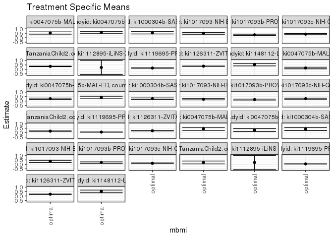

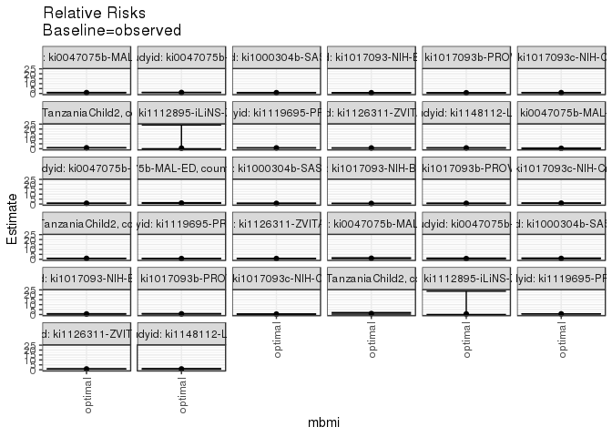

## Results Table

### Parameter: TSM

| agecat | studyid | country | intervention_level | baseline_level | estimate | ci_lower | ci_upper |
| --- | --- | --- | --- | --- | --- | --- | --- |
| 0-24 months | ki0047075b-MAL-ED | BANGLADESH | optimal | NA | 0.5273831 | 0.3997130 | 0.6550531 |
| 0-24 months | ki0047075b-MAL-ED | INDIA | optimal | NA | 0.6085489 | 0.4988266 | 0.7182711 |
| 0-24 months | ki1000304b-SAS-CompFeed | INDIA | optimal | NA | 0.5511415 | 0.4212114 | 0.6810717 |
| 0-24 months | ki1017093-NIH-Birth | BANGLADESH | optimal | NA | 0.4966873 | 0.3886534 | 0.6047213 |
| 0-24 months | ki1017093b-PROVIDE | BANGLADESH | optimal | NA | 0.3225414 | 0.2487176 | 0.3963653 |
| 0-24 months | ki1017093c-NIH-Crypto | BANGLADESH | optimal | NA | 0.4044998 | 0.3381944 | 0.4708053 |
| 0-24 months | ki1066203-TanzaniaChild2 | TANZANIA, UNITED REPUBLIC OF | optimal | NA | 0.3364789 | 0.3076181 | 0.3653397 |
| 0-24 months | ki1112895-iLiNS-Zinc | BURKINA FASO | optimal | NA | 0.2121501 | -0.5960632 | 1.0203634 |
| 0-24 months | ki1119695-PROBIT | BELARUS | optimal | NA | 0.1468344 | 0.1274721 | 0.1661967 |
| 0-24 months | ki1126311-ZVITAMBO | ZIMBABWE | optimal | NA | 0.3579726 | 0.3392015 | 0.3767437 |
| 0-24 months | ki1148112-LCNI-5 | MALAWI | optimal | NA | 0.5318262 | 0.3862939 | 0.6773585 |
| 0-6 months | ki0047075b-MAL-ED | BANGLADESH | optimal | NA | 0.1520012 | 0.0608752 | 0.2431273 |
| 0-6 months | ki0047075b-MAL-ED | INDIA | optimal | NA | 0.2618896 | 0.1899698 | 0.3338095 |
| 0-6 months | ki0047075b-MAL-ED | TANZANIA, UNITED REPUBLIC OF | optimal | NA | 0.4000964 | 0.2556967 | 0.5444961 |
| 0-6 months | ki1000304b-SAS-CompFeed | INDIA | optimal | NA | 0.2712990 | 0.1899809 | 0.3526170 |
| 0-6 months | ki1017093-NIH-Birth | BANGLADESH | optimal | NA | 0.2006365 | 0.1317919 | 0.2694811 |
| 0-6 months | ki1017093b-PROVIDE | BANGLADESH | optimal | NA | 0.1691078 | 0.1117349 | 0.2264807 |
| 0-6 months | ki1017093c-NIH-Crypto | BANGLADESH | optimal | NA | 0.2651438 | 0.2034131 | 0.3268744 |
| 0-6 months | ki1066203-TanzaniaChild2 | TANZANIA, UNITED REPUBLIC OF | optimal | NA | 0.1771449 | 0.1542805 | 0.2000093 |
| 0-6 months | ki1119695-PROBIT | BELARUS | optimal | NA | 0.0689395 | 0.0557723 | 0.0821066 |
| 0-6 months | ki1126311-ZVITAMBO | ZIMBABWE | optimal | NA | 0.2176659 | 0.2015357 | 0.2337961 |
| 6-24 months | ki0047075b-MAL-ED | BANGLADESH | optimal | NA | 0.4303343 | 0.2585197 | 0.6021488 |
| 6-24 months | ki0047075b-MAL-ED | INDIA | optimal | NA | 0.2935269 | 0.1332200 | 0.4538338 |
| 6-24 months | ki1000304b-SAS-CompFeed | INDIA | optimal | NA | 0.4167464 | 0.2431160 | 0.5903767 |
| 6-24 months | ki1017093-NIH-Birth | BANGLADESH | optimal | NA | 0.3358472 | 0.2097077 | 0.4619868 |
| 6-24 months | ki1017093b-PROVIDE | BANGLADESH | optimal | NA | 0.2035281 | 0.1240696 | 0.2829866 |
| 6-24 months | ki1017093c-NIH-Crypto | BANGLADESH | optimal | NA | 0.1182866 | 0.0718641 | 0.1647091 |
| 6-24 months | ki1066203-TanzaniaChild2 | TANZANIA, UNITED REPUBLIC OF | optimal | NA | 0.2162613 | 0.0537016 | 0.3788210 |
| 6-24 months | ki1112895-iLiNS-Zinc | BURKINA FASO | optimal | NA | 0.2121489 | -0.5916636 | 1.0159615 |
| 6-24 months | ki1119695-PROBIT | BELARUS | optimal | NA | 0.0531996 | 0.0429730 | 0.0634262 |
| 6-24 months | ki1126311-ZVITAMBO | ZIMBABWE | optimal | NA | 0.2046611 | 0.1855924 | 0.2237298 |
| 6-24 months | ki1148112-LCNI-5 | MALAWI | optimal | NA | 0.5141666 | 0.3619362 | 0.6663971 |

### Parameter: E(Y)

| agecat | studyid | country | intervention_level | baseline_level | estimate | ci_lower | ci_upper |
| --- | --- | --- | --- | --- | --- | --- | --- |
| 0-24 months | ki0047075b-MAL-ED | BANGLADESH | observed | NA | 0.6096427 | 0.5495478 | 0.6697376 |
| 0-24 months | ki0047075b-MAL-ED | INDIA | observed | NA | 0.6073122 | 0.5456605 | 0.6689638 |
| 0-24 months | ki1000304b-SAS-CompFeed | INDIA | observed | NA | 0.6849319 | 0.6416823 | 0.7281816 |
| 0-24 months | ki1017093-NIH-Birth | BANGLADESH | observed | NA | 0.6648294 | 0.6279021 | 0.7017566 |
| 0-24 months | ki1017093b-PROVIDE | BANGLADESH | observed | NA | 0.4534295 | 0.4156922 | 0.4911667 |
| 0-24 months | ki1017093c-NIH-Crypto | BANGLADESH | observed | NA | 0.4811020 | 0.4454433 | 0.5167607 |
| 0-24 months | ki1066203-TanzaniaChild2 | TANZANIA, UNITED REPUBLIC OF | observed | NA | 0.3455062 | 0.3262565 | 0.3647558 |
| 0-24 months | ki1112895-iLiNS-Zinc | BURKINA FASO | observed | NA | 0.3581202 | 0.3081587 | 0.4080817 |
| 0-24 months | ki1119695-PROBIT | BELARUS | observed | NA | 0.1675782 | 0.1486060 | 0.1865504 |
| 0-24 months | ki1126311-ZVITAMBO | ZIMBABWE | observed | NA | 0.4394835 | 0.4296668 | 0.4493002 |
| 0-24 months | ki1148112-LCNI-5 | MALAWI | observed | NA | 0.6358851 | 0.6032620 | 0.6685082 |
| 0-6 months | ki0047075b-MAL-ED | BANGLADESH | observed | NA | 0.3484583 | 0.2898243 | 0.4070923 |
| 0-6 months | ki0047075b-MAL-ED | INDIA | observed | NA | 0.3443081 | 0.2843757 | 0.4042406 |
| 0-6 months | ki0047075b-MAL-ED | TANZANIA, UNITED REPUBLIC OF | observed | NA | 0.4179288 | 0.3573915 | 0.4784661 |
| 0-6 months | ki1000304b-SAS-CompFeed | INDIA | observed | NA | 0.4266793 | 0.3926699 | 0.4606888 |
| 0-6 months | ki1017093-NIH-Birth | BANGLADESH | observed | NA | 0.3505110 | 0.3132126 | 0.3878095 |
| 0-6 months | ki1017093b-PROVIDE | BANGLADESH | observed | NA | 0.2480260 | 0.2153378 | 0.2807142 |
| 0-6 months | ki1017093c-NIH-Crypto | BANGLADESH | observed | NA | 0.3035092 | 0.2706977 | 0.3363207 |
| 0-6 months | ki1066203-TanzaniaChild2 | TANZANIA, UNITED REPUBLIC OF | observed | NA | 0.1926909 | 0.1767221 | 0.2086596 |
| 0-6 months | ki1119695-PROBIT | BELARUS | observed | NA | 0.0968056 | 0.0837720 | 0.1098393 |
| 0-6 months | ki1126311-ZVITAMBO | ZIMBABWE | observed | NA | 0.2866303 | 0.2776832 | 0.2955774 |
| 6-24 months | ki0047075b-MAL-ED | BANGLADESH | observed | NA | 0.4213881 | 0.3443947 | 0.4983816 |
| 6-24 months | ki0047075b-MAL-ED | INDIA | observed | NA | 0.4131519 | 0.3353900 | 0.4909138 |
| 6-24 months | ki1000304b-SAS-CompFeed | INDIA | observed | NA | 0.4911363 | 0.4468557 | 0.5354169 |
| 6-24 months | ki1017093-NIH-Birth | BANGLADESH | observed | NA | 0.5758029 | 0.5235463 | 0.6280595 |
| 6-24 months | ki1017093b-PROVIDE | BANGLADESH | observed | NA | 0.3001248 | 0.2580730 | 0.3421766 |
| 6-24 months | ki1017093c-NIH-Crypto | BANGLADESH | observed | NA | 0.2651681 | 0.2267768 | 0.3035593 |
| 6-24 months | ki1066203-TanzaniaChild2 | TANZANIA, UNITED REPUBLIC OF | observed | NA | 0.2281841 | 0.2074240 | 0.2489442 |
| 6-24 months | ki1112895-iLiNS-Zinc | BURKINA FASO | observed | NA | 0.3576426 | 0.3076810 | 0.4076041 |
| 6-24 months | ki1119695-PROBIT | BELARUS | observed | NA | 0.0805015 | 0.0662718 | 0.0947312 |
| 6-24 months | ki1126311-ZVITAMBO | ZIMBABWE | observed | NA | 0.2441589 | 0.2334420 | 0.2548758 |
| 6-24 months | ki1148112-LCNI-5 | MALAWI | observed | NA | 0.5983752 | 0.5627152 | 0.6340352 |

### Parameter: RR

| agecat | studyid | country | intervention_level | baseline_level | estimate | ci_lower | ci_upper |
| --- | --- | --- | --- | --- | --- | --- | --- |
| 0-24 months | ki0047075b-MAL-ED | BANGLADESH | optimal | observed | 0.8650691 | 0.7001254 | 1.0688722 |
| 0-24 months | ki0047075b-MAL-ED | INDIA | optimal | observed | 1.0020363 | 0.8598108 | 1.1677881 |
| 0-24 months | ki1000304b-SAS-CompFeed | INDIA | optimal | observed | 0.8046661 | 0.6355246 | 1.0188238 |
| 0-24 months | ki1017093-NIH-Birth | BANGLADESH | optimal | observed | 0.7470899 | 0.6095098 | 0.9157250 |
| 0-24 months | ki1017093b-PROVIDE | BANGLADESH | optimal | observed | 0.7113376 | 0.5758598 | 0.8786881 |
| 0-24 months | ki1017093c-NIH-Crypto | BANGLADESH | optimal | observed | 0.8407777 | 0.7286398 | 0.9701737 |
| 0-24 months | ki1066203-TanzaniaChild2 | TANZANIA, UNITED REPUBLIC OF | optimal | observed | 0.9738724 | 0.9127055 | 1.0391386 |
| 0-24 months | ki1112895-iLiNS-Zinc | BURKINA FASO | optimal | observed | 0.5923992 | 0.0145713 | 24.0840313 |
| 0-24 months | ki1119695-PROBIT | BELARUS | optimal | observed | 0.8762142 | 0.8353512 | 0.9190761 |
| 0-24 months | ki1126311-ZVITAMBO | ZIMBABWE | optimal | observed | 0.8145303 | 0.7774995 | 0.8533247 |
| 0-24 months | ki1148112-LCNI-5 | MALAWI | optimal | observed | 0.8363559 | 0.6405249 | 1.0920592 |
| 0-6 months | ki0047075b-MAL-ED | BANGLADESH | optimal | observed | 0.4362107 | 0.2468969 | 0.7706853 |
| 0-6 months | ki0047075b-MAL-ED | INDIA | optimal | observed | 0.7606258 | 0.6243698 | 0.9266169 |
| 0-6 months | ki0047075b-MAL-ED | TANZANIA, UNITED REPUBLIC OF | optimal | observed | 0.9573314 | 0.6813433 | 1.3451125 |
| 0-6 months | ki1000304b-SAS-CompFeed | INDIA | optimal | observed | 0.6358381 | 0.4540787 | 0.8903525 |
| 0-6 months | ki1017093-NIH-Birth | BANGLADESH | optimal | observed | 0.5724114 | 0.4152410 | 0.7890715 |
| 0-6 months | ki1017093b-PROVIDE | BANGLADESH | optimal | observed | 0.6818148 | 0.4964260 | 0.9364364 |
| 0-6 months | ki1017093c-NIH-Crypto | BANGLADESH | optimal | observed | 0.8735937 | 0.7110538 | 1.0732886 |
| 0-6 months | ki1066203-TanzaniaChild2 | TANZANIA, UNITED REPUBLIC OF | optimal | observed | 0.9193218 | 0.8338397 | 1.0135671 |
| 0-6 months | ki1119695-PROBIT | BELARUS | optimal | observed | 0.7121431 | 0.6527395 | 0.7769529 |
| 0-6 months | ki1126311-ZVITAMBO | ZIMBABWE | optimal | observed | 0.7593960 | 0.7105166 | 0.8116379 |
| 6-24 months | ki0047075b-MAL-ED | BANGLADESH | optimal | observed | 1.0212302 | 0.7093316 | 1.4702728 |
| 6-24 months | ki0047075b-MAL-ED | INDIA | optimal | observed | 0.7104575 | 0.4314438 | 1.1699089 |
| 6-24 months | ki1000304b-SAS-CompFeed | INDIA | optimal | observed | 0.8485351 | 0.5708952 | 1.2611979 |
| 6-24 months | ki1017093-NIH-Birth | BANGLADESH | optimal | observed | 0.5832677 | 0.4098404 | 0.8300823 |
| 6-24 months | ki1017093b-PROVIDE | BANGLADESH | optimal | observed | 0.6781448 | 0.4723626 | 0.9735748 |
| 6-24 months | ki1017093c-NIH-Crypto | BANGLADESH | optimal | observed | 0.4460815 | 0.3123256 | 0.6371194 |
| 6-24 months | ki1066203-TanzaniaChild2 | TANZANIA, UNITED REPUBLIC OF | optimal | observed | 0.9477490 | 0.4493571 | 1.9989183 |
| 6-24 months | ki1112895-iLiNS-Zinc | BURKINA FASO | optimal | observed | 0.5931869 | 0.0148981 | 23.6184291 |
| 6-24 months | ki1119695-PROBIT | BELARUS | optimal | observed | 0.6608522 | 0.6028040 | 0.7244902 |
| 6-24 months | ki1126311-ZVITAMBO | ZIMBABWE | optimal | observed | 0.8382291 | 0.7722986 | 0.9097879 |
| 6-24 months | ki1148112-LCNI-5 | MALAWI | optimal | observed | 0.8592713 | 0.6443340 | 1.1459074 |